# Lai Study 1 replication with VH estimators

Technical review of historical comparability, reporting scale, and slope-SD diagnostics

## Technical summary

The replication succeeds on its primary like-for-like point-estimate check. On Lai’s historical reporting scale, our dual-BLUP analogue has negative bias near $-.02$ for every random-effect correlation, closely matching Lai’s original **dual-EB** series. The previously suspected sign disagreement came from comparing that dual method with Lai’s separate slope-only EB series, whose bias changes sign with the random-effect correlation. Our 2S-PA and MSEM analogues also remain close to zero, as in the original results.

That conclusion is scale-specific. On the raw and common latent-slope-SD views, the dual-BLUP estimator is centrally near zero (with rare, very large failures), so much of its historical negative bias is attributable to Lai’s method-specific EB-slope-SD multiplier. In contrast, closed-form OLS remains negatively biased on the common scale, while Fuller, Fuller alpha-stepdown, 2S-PA, and MSEM are generally much closer to zero.

The interval results from the seven-method run are encouraging but not exact replications: our 2S-PA is somewhat conservative and our **VH/Mplus MSEM** somewhat anti-conservative relative to Lai’s original summaries, especially at $J=30$. A historical-only eighth method now reproduces Lai’s original OpenMx MSEM and obtains the standardized estimate and delta-method SE directly from `mxSE(stdbeta)`. It is added to the historical panels when its separate array has been completed and aggregated; it never enters the seven-method VH panels. Lai’s 2S-PAB and slope-only EB variants remain outside this refresh.

The production aggregate contains 486 DGM conditions, 7 methods, and 2,430,000 simulated data sets per raw reporting view. Its source is /proj/mnhallqlab/projects/blup_unshrinking/outputs/lai_study1_vh_production_20260731/lai_study1_vh_summary.csv.

### Result at a glance

For the historical comparison at $\beta_{Zu1}=.4$, the naïve dual-BLUP median trimmed bias is negative at every random-effect correlation (rho = -0.5: -0.022; rho = 0: -0.023; rho = 0.5: -0.021). This closely reproduces Lai’s original dual-EB $(u_0+u_1)$ series. The correlation-signed pattern in the original paper belongs to the two *slope-only* EB specifications, which are not in the seven-method VH bundle. 2S-PA remains near zero (rho = -0.5: 0.000; rho = 0: -0.000; rho = 0.5: -0.000) and the VH/Mplus MSEM is small and positive (rho = -0.5: 0.002; rho = 0: 0.001; rho = 0.5: 0.000) on this historical view. The source-faithful OpenMx MSEM add-on is complete and included in the historical panels. Its correlation-specific medians are rho = -0.5: 0.000; rho = 0: -0.000; rho = 0.5: -0.000.

On the common latent-SD VH view, the naïve dual-BLUP median is not itself the main issue; its distribution has 11 conditions with $|\mathrm{mean\ bias}| > 1$, including a maximum of 5930.0. The report therefore shows its central behavior and its rare instability in separate panels rather than letting those failures flatten every other method’s plot.

### Replication goals and current status

Extent to which the refreshed study meets the goals in README.md

| Goal | Status | Evidence_or_limit |
| --- | --- | --- |
| Preserve Lai Study 1 DGM and 486-cell grid | Complete | Audited in Section 1; 5,000 replications per cell |
| Use the seven VH Study 2 estimators | Complete | All seven methods appear in the common-scale bias and inference panels |
| Add Lai’s original OpenMx MSEM without changing the VH bundle | Complete | complete and included in the historical panels |
| Retain raw, common latent-SD, and historical scales | Complete | All three reporting views are explicit and separately labeled |
| Track VH and original-Lai eligibility | Complete | Both rules and their overlap are reported in Section 6 |
| Diagnose slope SD and posterior reliability | Complete | DGM and fitted slope-SD diagnostics are shown in Section 5 |
| Reproduce Lai Figures 2–4 exactly | Partial | The original MSEM now uses Lai’s p value and delta-method SE; 2S-PAB and two slope-only EB methods remain absent |

The design therefore answers the intended codebase-validation question, but does not replace a strict rerun of all six original methods. Numeric comparisons below use a frozen summary extracted from Lai’s original `results-sim1-revise2.rds` at commit `9ffe53168f6bb04e13ef977dc19a8d953d0bf29d`.

## Methods and terminology

The target is the effect of the level-2 covariate $Z$ on the random slope $u_1$. “Dual” means that the stage-2 regression uses both the random intercept $u_0$ and random slope $u_1$ as predictors; this is important when those random effects are correlated.

Estimator terminology used throughout this report

| Method | Stage-2 predictor or model | Interpretive role |
| --- | --- | --- |
| Oracle dual | True simulated u0 and u1 | Simulation benchmark; not available in applications |
| Naive dual BLUP | Empirical-Bayes (BLUP) u0 and u1, treated as observed | Shows attenuation/instability from ignoring first-stage uncertainty |
| Closed-form dual | Closed-form corrected u0 and u1, treated as observed | Separates corrected-score construction from stage-2 EIV correction |
| Fuller closed-form | Closed-form corrected scores with their measurement-error covariance | EIV-style correction using estimated first-stage error covariance |
| Fuller alpha-stepdown | Fuller correction with alpha stepdown for a guarded correction | Stabilized Fuller variant in the VH Study 2 bundle |
| 2S-PA | Lai two-stage path-analysis model fitted in OpenMx | Direct Lai-method overlap for historical comparison |
| MSEM (VH/Mplus) | Joint multilevel structural-equation model fitted in Mplus | VH Study 2 latent-variable benchmark; historical comparison diagnostic |
| MSEM (original OpenMx; historical only) | Lai’s original cross-level OpenMx MSEM; direct standardized algebra and mxSE delta-method SE | Source-faithful historical benchmark; excluded from VH-primary seven-method comparisons |

The first three methods use a two-predictor observed-score regression in stage 2. The distinction is whether those predictors are true random effects, shrunken EB estimates, or closed-form corrected scores. The Fuller methods also propagate the estimated measurement-error covariance into the stage-2 correction. 2S-PA and both MSEM implementations instead fit their own latent-variable/path models. The VH/Mplus MSEM is one of the seven primary methods. The original OpenMx MSEM is an eighth, historical-only diagnostic: its standardized effect and SE jointly account for uncertainty in the fitted latent slope SD through OpenMx’s delta method.

## 1. DGM audit: the Lai grid and the estimand are explicit

The review starts by auditing the condition grid, rather than inferring the design from a plotted result. The external-outcome effect of the random intercept is fixed at $\beta_{zu0}=.4$; the focal slope effect is $\beta_{zu1}$. The summary rows below use the raw reporting view only, so reporting-scale rows do not duplicate conditions.

Lai Study 1 condition grid represented in the VH replication

| factor | levels |
| --- | --- |
| Clusters | 30, 100, 500 |
| Cluster size | 3, 10, 25 |
| ICC | 0.05, 0.2, 0.5 |
| Slope/intercept variance ratio | 0.5, 1, 2 |
| Random-effect correlation | -0.5, 0, 0.5 |
| Slope external effect | 0, 0.4 |

The condition count is 486. The population slope SD and posterior slope reliability below are DGM quantities, not post-hoc calibration targets; they provide the reference for the later slope-SD and reliability diagnostics.

| Population slope SD range | Posterior reliability range | Replications per condition |
| --- | --- | --- |
| 0.158113883008419 to 1 | 0.073 to 0.981 | 5000 |

## 2. Historical Figure 2 analogue: compare like with like

This panel is the primary visual comparison with Lai’s Figure 2. It contains the three methods already available from the VH run (naive dual BLUP, 2S-PA, and VH/Mplus MSEM) plus Lai’s original OpenMx MSEM when the additive historical run is complete. It uses Lai’s method-specific historical standardization, Lai’s `status_code == 0` retention rule, and a 20%-trimmed Monte Carlo bias. Those choices are deliberately different from the VH-primary analysis below.

Lai’s published Figure 2 code plots six methods: 2S-PA, 2S-PAB, MSEM, EB $(u_0+u_1)$, centered EB, and uncentered EB. This analogue retains only the directly corresponding 2S-PA and dual-EB series, the current VH/Mplus MSEM diagnostic, and—when available—a source-faithful rerun of the original OpenMx MSEM. It cannot test the other three lines. The original plotting code is available in the [Lai supplementary repository](https://github.com/marklhc/2spa-random-slopes-supp/blob/9ffe53168f6bb04e13ef977dc19a8d953d0bf29d/notebooks/_sim1_results_supp.qmd). The colors preserve that notebook’s ggplot2 mapping: 2S-PA is red, the **original OpenMx MSEM** is the original green, and dual EB is cyan. The VH/Mplus MSEM uses a darker green so the two implementations are not conflated. Colors assigned to VH-only methods in later panels are stable extensions, not claims that those methods correspond to omitted Lai methods.

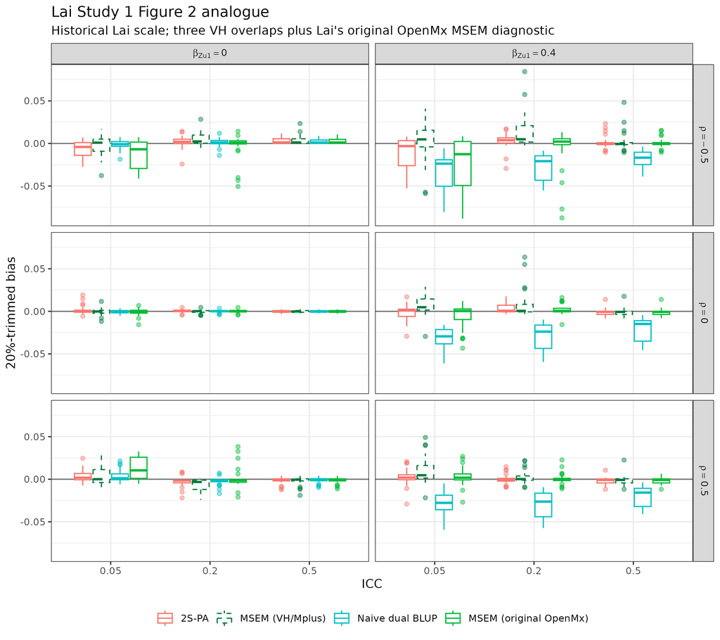

Lai Study 1 Figure 2 analogue: historical reporting scale and Lai eligibility rule.

Availability and retention in the historical comparison view

| Method | conditions | Mean scale availability | Mean Lai eligibility | Mean retained replications |
| --- | --- | --- | --- | --- |
| 2S-PA | 486 | 96.5% | 91.3% | 4463.5 |
| MSEM (VH/Mplus) | 486 | 100.0% | 98.9% | 4945.9 |
| MSEM (original OpenMx) | 486 | 96.4% | 99.0% | 4775.1 |
| Naive dual BLUP | 486 | 92.6% | 92.6% | 4630.2 |

Current versus original median 20%-trimmed bias at beta[Z.u1] = .4, summarized over the remaining DGM factors

| Method | Correlation | Current median bias | Original Lai median bias | Difference |
| --- | --- | --- | --- | --- |
| 2S-PA | -0.5 | 0.000 | 0.001 | -0.000 |
| 2S-PA | 0.0 | -0.000 | -0.000 | 0.000 |
| 2S-PA | 0.5 | -0.000 | -0.001 | 0.001 |
| MSEM (original OpenMx) | -0.5 | 0.000 | 0.000 | 0.000 |
| MSEM (original OpenMx) | 0.0 | -0.000 | -0.001 | 0.000 |
| MSEM (original OpenMx) | 0.5 | -0.000 | -0.001 | 0.001 |
| MSEM (VH/Mplus) | -0.5 | 0.002 | 0.000 | 0.002 |
| MSEM (VH/Mplus) | 0.0 | 0.001 | -0.001 | 0.001 |
| MSEM (VH/Mplus) | 0.5 | 0.000 | -0.001 | 0.001 |
| Naive dual BLUP | -0.5 | -0.022 | -0.024 | 0.003 |
| Naive dual BLUP | 0.0 | -0.023 | -0.026 | 0.002 |
| Naive dual BLUP | 0.5 | -0.021 | -0.024 | 0.002 |

### Historical coverage and Type I error analogues

The next two panels mimic Lai’s Figures 3 and 4 using the same historical methods, historical scale, and `status_code == 0` retention rule. Coverage is the proportion of retained 95% intervals containing the truth. The Type I panel is limited to $\beta_{Zu1}=0$ and uses two-sided 95% CI exclusion as the rejection rule for the three methods reconstructed from the VH output. The original OpenMx MSEM add-on instead stores and uses Lai’s exact normal-Wald `p < .05` definition. These rules ordinarily agree, but keeping the provenance explicit prevents the reconstructed VH/Mplus interval from being mistaken for Lai’s delta-method interval.

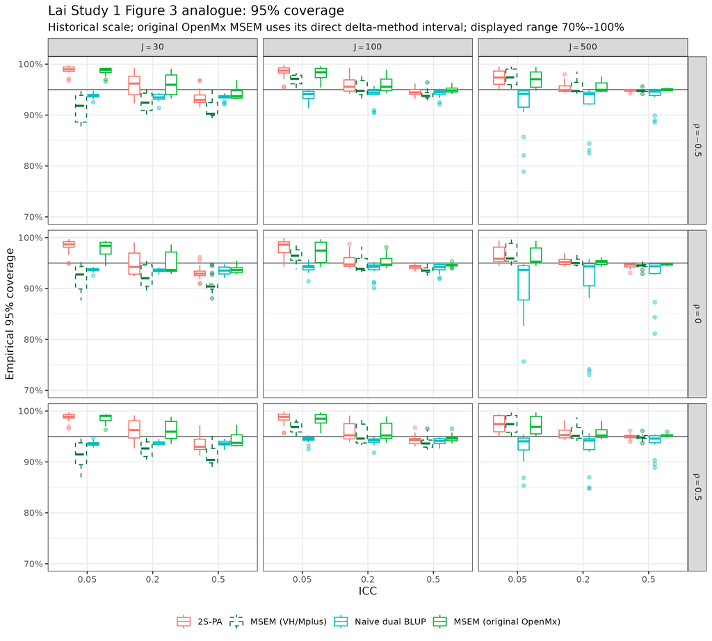

Figure 3 analogue: empirical 95% coverage under historical Lai reporting and retention.

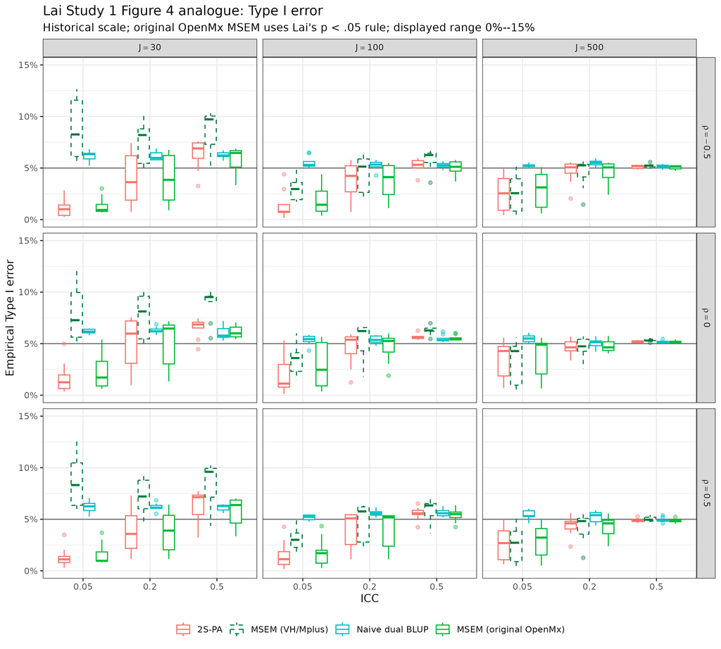

Figure 4 analogue: CI-based empirical Type I error under historical Lai reporting and retention.

Current and original condition-weighted interval performance; reconstructed VH methods use CI exclusion, while original OpenMx MSEM uses Lai’s stored normal-Wald p value

| Method | Coverage conditions | Mean coverage | Original coverage | Median coverage | Type I conditions | Mean Type I error | Original Type I error | Median Type I error | Mean retained replications |
| --- | --- | --- | --- | --- | --- | --- | --- | --- | --- |
| 2S-PA | 486 | 95.9% | 94.6% | 95.2% | 243 | 4.0% | 4.5% | 4.7% | 4463.5 |
| MSEM (original OpenMx) | 486 | 95.9% | 95.9% | 95.3% | 243 | 4.0% | 4.2% | 4.8% | 4775.1 |
| MSEM (VH/Mplus) | 486 | 94.3% | 95.9% | 94.5% | 243 | 5.6% | 4.2% | 5.4% | 4945.9 |
| Naive dual BLUP | 486 | 93.3% | 93.2% | 93.9% | 243 | 5.6% | 5.8% | 5.5% | 4630.2 |

The reference lines are .95 for coverage and .05 for Type I error. The table uses condition-level rates (not a pooled replication denominator), so it describes how performance varies across the Lai design. Interpret a departure from either reference together with the matching bias panel and the number of retained replications: a nominal interval result can change when the historical reporting multiplier or status-code retention changes.

For these three overlapping methods, 2S-PA is slightly conservative overall: mean coverage is 95.9% and mean CI-based Type I error is 4.0%. Naïve dual BLUP averages 93.3% coverage and 5.6% Type I error; MSEM averages 94.3% and 5.6%, respectively. The strongest MSEM departure is in the $J=30$ cells, where its mean coverage is 91.8% and its mean Type I error is 8.1%. The source-faithful OpenMx MSEM averages 95.9% coverage and 4.0% Type I error overall; at J = 30 the corresponding values are 96.0% and 4.0%. Relative to Lai’s original summaries, current dual-BLUP coverage and Type I error are close. Current 2S-PA is more conservative (about 96% coverage and 4% Type I error versus about 95% and 4.5% originally), while MSEM is more anti-conservative (about 94% and 5.7% versus about 96% and 4.2%). The historical OpenMx row now separates a model/software/interval-construction difference from a DGM difference. Those are practical inference differences worth tracing; they do not overturn the point-estimate replication.

### Paired Mplus–OpenMx audit: two mechanisms, not one

The completed paired-engine audit regenerates the exact data for two close and two maximally divergent seed/condition pairs, then retains all Mplus input and output files. It compares the current Mplus specification (whose retained output identifies its default estimator as MLR), an explicit-ML version of the same model, MLR and ML versions with the standardized product declared in `MODEL CONSTRAINT`, and the original OpenMx model. This separates a difference in standard-error construction from a difference in the fitted numerical solution.

One-to-one regenerated-data audit. The same current-default Mplus and OpenMx values reproduce their saved production values exactly.

| Condition | Replication | Seed class | Mplus fit | Mplus standardized estimate | Mplus SE | OpenMx standardized estimate | OpenMx delta SE | Mplus − OpenMx estimate |
| --- | --- | --- | --- | --- | --- | --- | --- | --- |
| 1 | 2089 | Most divergent paired solution | Current default (MLR; fixed multiplier) | 8.098 | 0.496 | -0.934 | 10.392 | 9.032 |
| 1 | 2089 | Most divergent paired solution | Current default (MLR; product delta method) | 8.098 | 0.495 | -0.934 | 10.392 | 9.006 |
| 1 | 2089 | Most divergent paired solution | ML constraint (product delta method) | 8.098 | 2.841 | -0.934 | 10.392 | 9.006 |
| 1 | 2721 | Closest paired solution | Current default (MLR; fixed multiplier) | -0.287 | 0.405 | -0.287 | 0.359 | 0.000 |
| 1 | 2721 | Closest paired solution | Current default (MLR; product delta method) | -0.287 | 0.333 | -0.287 | 0.359 | 0.000 |
| 1 | 2721 | Closest paired solution | ML constraint (product delta method) | -0.287 | 0.359 | -0.287 | 0.359 | 0.000 |
| 60 | 808 | Most divergent paired solution | Current default (MLR; fixed multiplier) | -11.685 | 0.698 | 0.068 | 0.300 | -11.754 |
| 60 | 808 | Most divergent paired solution | Current default (MLR; product delta method) | -11.685 | 0.700 | 0.068 | 0.300 | -11.775 |
| 60 | 808 | Most divergent paired solution | ML constraint (product delta method) | -11.685 | 2.148 | 0.068 | 0.300 | -11.775 |
| 60 | 3213 | Closest paired solution | Current default (MLR; fixed multiplier) | -0.047 | 0.273 | -0.047 | 0.232 | 0.000 |
| 60 | 3213 | Closest paired solution | Current default (MLR; product delta method) | -0.047 | 0.278 | -0.047 | 0.232 | 0.000 |
| 60 | 3213 | Closest paired solution | ML constraint (product delta method) | -0.047 | 0.232 | -0.047 | 0.232 | 0.000 |

In the closest pair, the Mplus ML constrained product and OpenMx agree to 0.000286 on the standardized estimate, and their delta-method SEs are 0.359 and 0.359. This verifies that the two model parameterizations can represent the same fitted solution. In the selected divergent pair, the Mplus ML constrained estimate is 8.072 whereas OpenMx returns -0.934; changing Mplus from its default MLR to ML does not remove that discrepancy. Thus this part of the gap is optimizer/weak-identification behavior, not a reporting-scale transformation.

For that same stable pair, the current MLR fixed-multiplier SE is 0.405, the MLR product-delta SE is 0.333, and the ML product-delta SE is 0.359. Thus both the post-hoc reporting rule and the MLR-versus-ML choice can move an interval even when the fitted point estimate agrees.

The divergent Mplus outputs nevertheless state that estimation terminated normally. They also report information-matrix condition ratios of about $1.22\times10^{-14}$ and $3.61\times10^{-16}$ and explicitly flag possible model nonidentification. The saved current-run rows mark those fits as noncritical, because the VH Mplus-warning screen does not currently treat the `CONDITION NUMBER` / `MODEL NONIDENTIFICATION` wording as a critical warning. This is therefore a concrete eligibility-screening gap, rather than evidence that the two models are stably estimating different parameters.

The audit also identifies an inference mismatch in the current VH extraction: its historical-scale Mplus row takes the SE of the raw $z \leftarrow s$ path and multiplies it by the fitted slope SD. That treats the fitted SD as fixed. Lai’s OpenMx result instead obtains `mxSE(stdbeta)` for the product itself, including uncertainty in the slope variance and its covariance with the path. The ML `MODEL CONSTRAINT` audit is the direct Mplus analogue of the latter. This difference can be material, but it is not sufficient to explain every outlying seed because some paired fits have different point estimates before standardization.

At the condition-summary level, the historical OpenMx coverage is also based on a more selective usable-interval population. At $J=30$, OpenMx retains a mean 91.3% of replications for interval calculation (with some cells near 50%), while current Mplus retains about 98.5%. Therefore the high historical OpenMx coverage should not be read as an engine-only advantage until coverage is recomputed under a common numerical-eligibility rule and a common product-delta estimand.

If `params$historical_figure_reference` points to a locally saved image of the published Figure 2, render it alongside this panel during review. The visual comparison should ask whether the sign and correlation pattern agree, not whether the current all-method VH analysis matches a method-specific Lai scale.

## 3. VH-primary performance: seven methods on a common latent-SD scale

The VH-primary view uses the `latent_sd` reporting scale and the VH eligibility rule. Each point in the next plot is a condition-level Monte Carlo mean bias; the boxplots summarize the 486-condition distribution rather than pooling replications across different DGMs.

Central performance and extreme condition-level bias on the VH-primary scale

| Method | Median bias | Median \|bias\| | Maximum \|bias\| | Conditions: \|bias\| > .1 | Conditions: \|bias\| > 1 |
| --- | --- | --- | --- | --- | --- |
| Closed-form dual | -0.016 | 0.021 | 0.14 | 27 | 0 |
| Fuller alpha-stepdown | 0.000 | 0.002 | 0.08 | 0 | 0 |
| Fuller closed-form | 0.000 | 0.002 | 0.09 | 0 | 0 |
| 2S-PA | 0.001 | 0.003 | 0.09 | 0 | 0 |
| MSEM (VH/Mplus) | 0.001 | 0.004 | 0.16 | 4 | 0 |
| Naive dual BLUP | 0.001 | 0.004 | 5929.96 | 13 | 11 |
| Oracle dual | 0.000 | 0.001 | 0.01 | 0 | 0 |

Condition-weighted VH-primary performance summary

| method_label | conditions | Mean bias | Median \|bias\| | Mean RMSE | Mean coverage | Mean VH eligibility |
| --- | --- | --- | --- | --- | --- | --- |
| Oracle dual | 486 | 0.000 | 0.001 | 0.122 | 94.5% | 100.0% |
| Naive dual BLUP | 486 | 4.353 | 0.004 | 1278.257 | 94.2% | 90.7% |
| Closed-form dual | 486 | -0.027 | 0.021 | 0.101 | 85.1% | 100.0% |
| Fuller closed-form | 486 | 0.001 | 0.002 | 0.203 | 96.0% | 100.0% |
| Fuller alpha-stepdown | 486 | -0.001 | 0.002 | 0.187 | 95.9% | 100.0% |
| 2S-PA | 486 | 0.003 | 0.003 | 0.243 | 95.9% | 89.3% |
| MSEM (VH/Mplus) | 486 | 0.008 | 0.004 | 0.328 | 94.3% | 98.9% |

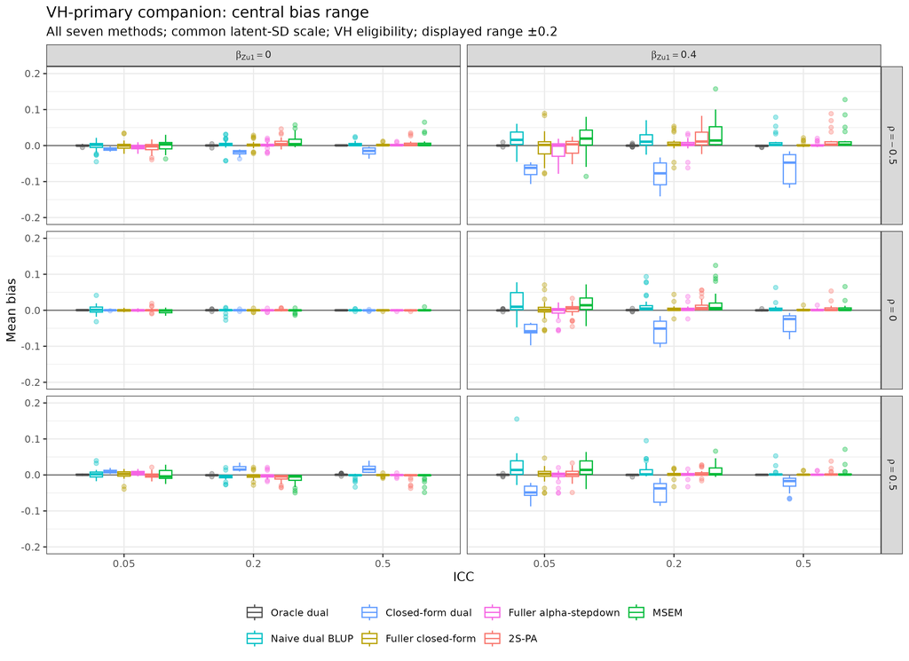

VH-primary central-range companion. The fixed ±0.2 range is intentional; rare larger failures are shown in the following diagnostic.

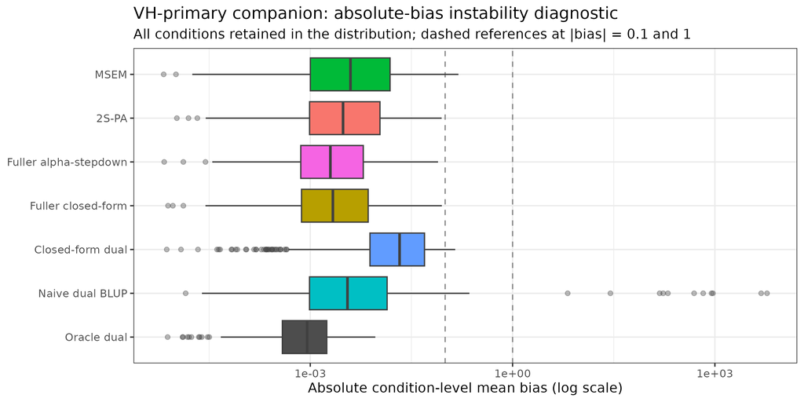

Full absolute-bias distribution on a log scale. This retains, rather than trims, rare unstable conditions.

The central-range panel shows that the closed-form dual estimator is the main source of systematic negative central bias when $\beta_{Zu1}=.4$, while the two Fuller estimators, 2S-PA, MSEM, and oracle are generally much closer to zero. The log-scale diagnostic adds the complementary fact that naïve dual BLUP has rare, severe failures even though its median is near zero. Neither claim is visible in the original unbounded all-method boxplot by itself.

### VH-primary coverage and Type I error companions

The following two panels extend the interval diagnostics to all seven VH methods, including Fuller closed-form and Fuller alpha-stepdown. They use the common latent-SD reporting view and VH primary eligibility rule. Unlike the three-method historical panels above, these are not Lai Figure 3/4 analogues: Fuller has no historical Lai method-specific standardization. A common constant scale does not alter interval inclusion or CI exclusion, but the explicit common-scale convention keeps the method comparison and retention rule aligned with the VH bias panels.

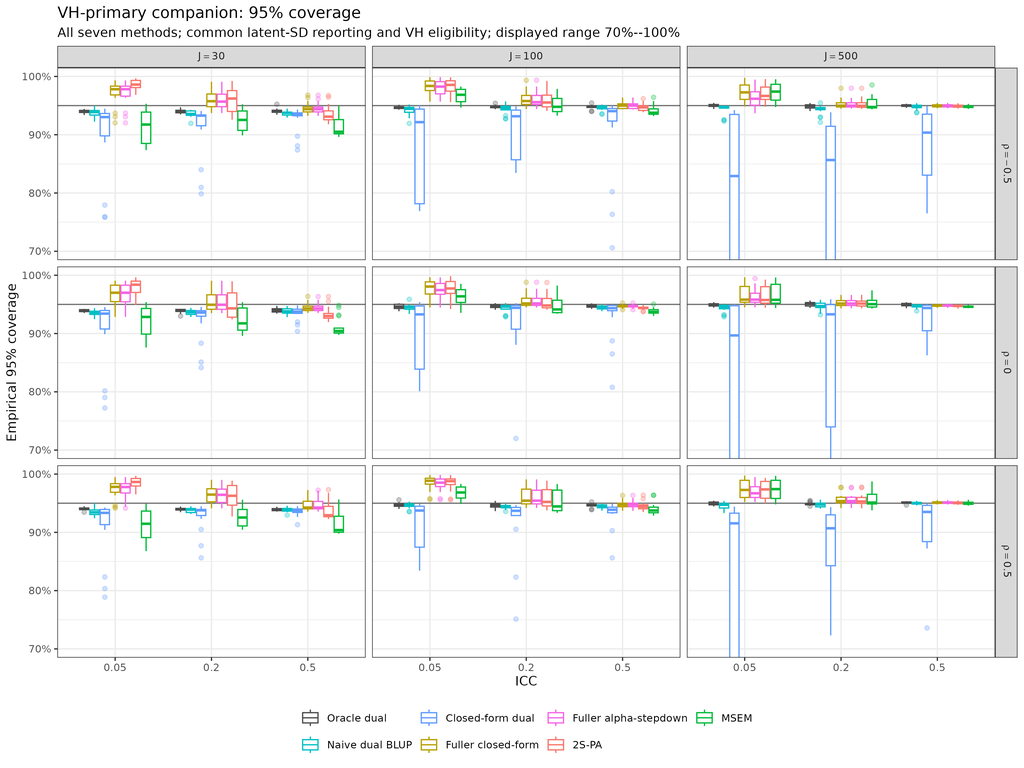

VH-primary companion: empirical 95% coverage for all seven methods.

The focused coverage panel makes departures around 95% readable. It intentionally clips values below 70%, so the full-range diagnostic below is required for judging catastrophic failure rather than only near-nominal performance.

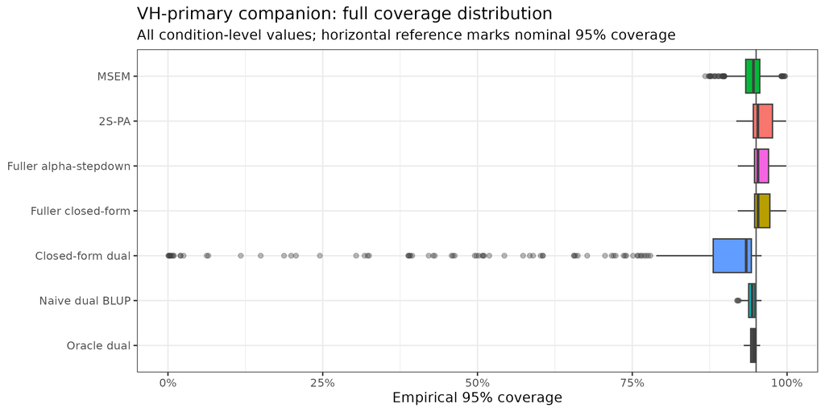

Full-range VH-primary coverage distribution. This exposes values hidden by the focused 70%–100% panel.

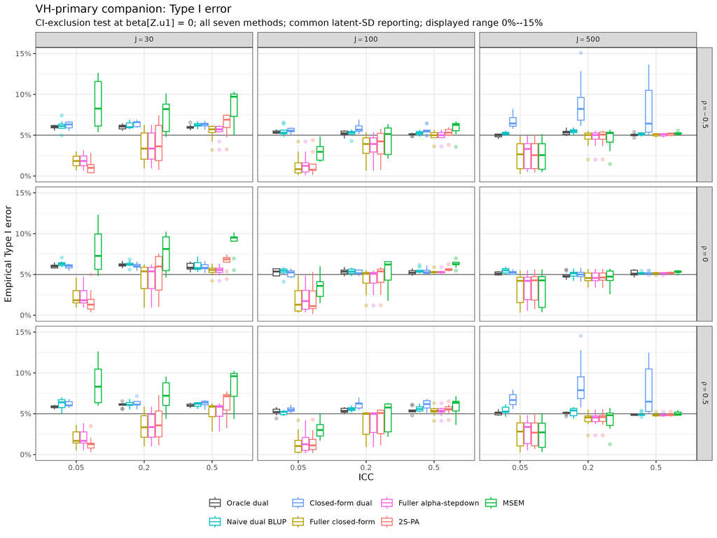

VH-primary companion: CI-based Type I error for all seven methods, at beta[Z.u1] = 0.

Condition-weighted VH-primary interval performance; Type I error is evaluated only when beta[Z.u1] = 0

| Method | Mean coverage | Mean Type I error | Mean retained replications |
| --- | --- | --- | --- |
| Closed-form dual | 85.1% | 6.2% | 5000.0 |
| Fuller alpha-stepdown | 95.9% | 3.9% | 5000.0 |
| Fuller closed-form | 96.0% | 3.8% | 5000.0 |
| 2S-PA | 95.9% | 4.0% | 4464.5 |
| MSEM (VH/Mplus) | 94.3% | 5.6% | 4946.0 |
| Naive dual BLUP | 94.2% | 5.6% | 4535.7 |
| Oracle dual | 94.5% | 5.5% | 5000.0 |

Closed-form dual is the clear interval failure: its condition-weighted mean coverage is 85.1%, with 55 conditions below 70% and a minimum near 0.1%. Both Fuller variants recover roughly 96% coverage and Type I error near 4%, with little practical separation between ordinary Fuller and alpha-stepdown. Naïve dual BLUP and MSEM are modestly anti-conservative overall; oracle is close to nominal. Read these averages with the faceted panels because small clusters and particular correlations concentrate the departures.

## 4. Reporting-scale sensitivity: separate rescaling from estimator behavior

Raw and latent-SD rows report the same fitted estimator on different common condition-level scales. The historical standardized row is different: for the directly comparable methods it preserves Lai’s method-specific multiplier. Consequently, this section is a diagnostic of reporting conventions, not a competition between differently scaled numerical values.

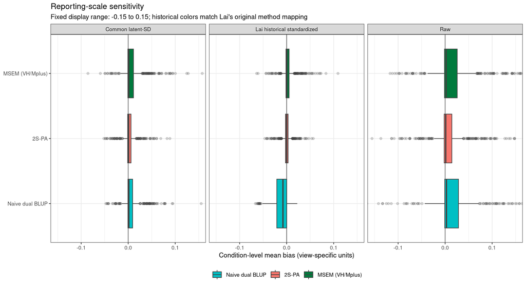

Central condition-level bias for the three overlapping methods under each reporting view. The fixed range makes shifts between views visible; tail failures are reported separately.

Method-specific historical scaling diagnostics

| method_label | Mean Lai historical multiplier | Availability |
| --- | --- | --- |
| Naive dual BLUP | 0.407 | 100.0% |
| 2S-PA | 0.493 | 100.0% |
| MSEM (VH/Mplus) | 0.475 | 100.0% |

The key finding is method-specific: the dual-BLUP distribution shifts downward on Lai’s historical view but is centrally near zero on both common views. Raw-to-latent-SD scaling alone cannot create or remove a bias pattern, because it is a fixed condition-level multiplier applied to both estimate and truth. The extra change on the historical view comes from using the observed EB-slope SD for the naïve method while retaining the true latent-slope SD in the benchmark. This is why a negative historical dual-EB bias can coexist with little central raw-coefficient bias.

## 5. Slope-SD and reliability diagnostics: test the calibration explanation

The posterior reliability plotted here is calculated from the true full two-dimensional random-effect covariance and Lai’s RMS-scaled within-cluster design. It should not be replaced by `lambda22` when random effects are correlated. The first plot removes duplicate values across the number of clusters and $\beta_{Zu1}$, neither of which enters the posterior-reliability calculation, and shows the remaining determinants explicitly.

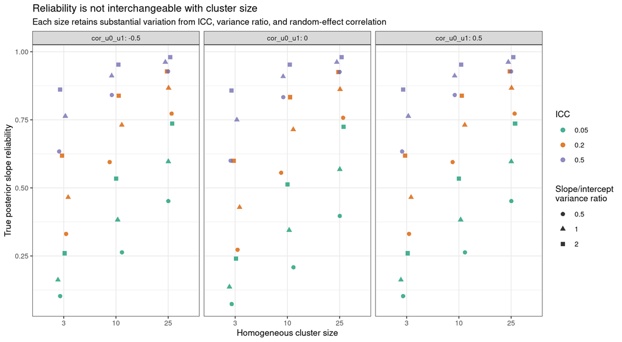

True posterior slope reliability by homogeneous cluster size, ICC, slope/intercept variance ratio, and random-effect correlation.

True posterior slope reliability varies substantially within every homogeneous cluster-size level

| clus_size | Minimum reliability | Median reliability | Maximum reliability |
| --- | --- | --- | --- |
| 3 | 0.073 | 0.465 | 0.862 |
| 10 | 0.208 | 0.731 | 0.953 |
| 25 | 0.397 | 0.867 | 0.981 |

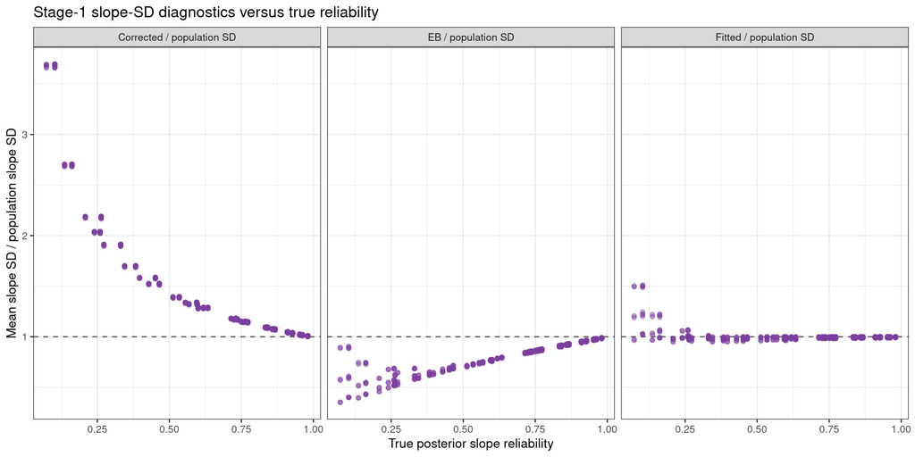

Stage-1 slope-SD diagnostics relative to the DGM population slope SD.

The slope-SD ratios use the same Stage-1 fit attached to the naive dual BLUP raw summary, avoiding duplicate copies of the diagnostics across reporting views. A ratio of one is a diagnostic reference, not a convergence criterion.

The reliability result is consistent with cluster size being an important determinant, but rejects the stronger claim that it is merely a proxy for cluster size: at size 3 the reliability spans approximately .07–.86, and at size 25 it still spans approximately .40–.98. The EB slope SD is most attenuated at low reliability, whereas the fitted slope SD remains close to the population slope SD across the reliability range. This makes the slope-SD correction a useful diagnostic for the observed bias pattern rather than a substitute for modelling reliability itself. Because reliability is emergent rather than independently randomized here, however, a trend against reliability in this study cannot be interpreted as the isolated causal effect of reliability; that is precisely the role of the direct calibration in VH Study 2.

## 6. Eligibility and convergence: compare the two retention rules directly

VH eligibility and original-Lai eligibility answer different questions. The historical rule retains runs with `status_code == 0`; the VH-primary rule also applies estimator-specific finite-estimate, finite-SE, design, and fit diagnostics. The following plot displays the average condition-level rate for each rule; it should accompany any comparison that changes the reporting scale or estimator bundle.

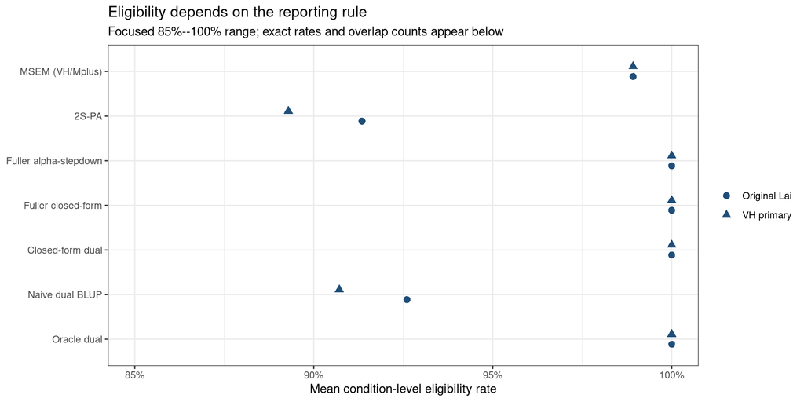

Average condition-level retention under the original-Lai and VH-primary rules.

Condition-averaged eligibility overlap and convergence

| method_label | VH eligible | Lai eligible | Both eligible (mean count) | Lai-only (mean count) | VH-only (mean count) | Convergence |
| --- | --- | --- | --- | --- | --- | --- |
| Oracle dual | 100.0% | 100.0% | 5000.0 | 0.0 | 0.0 | 100.0% |
| Naive dual BLUP | 90.7% | 92.6% | 4535.7 | 94.5 | 0.0 | 92.6% |
| Closed-form dual | 100.0% | 100.0% | 5000.0 | 0.0 | 0.0 | 100.0% |
| Fuller closed-form | 100.0% | 100.0% | 5000.0 | 0.0 | 0.0 | 100.0% |
| Fuller alpha-stepdown | 100.0% | 100.0% | 5000.0 | 0.0 | 0.0 | 100.0% |
| 2S-PA | 89.3% | 91.3% | 4464.5 | 102.8 | 0.0 | 89.3% |
| MSEM (VH/Mplus) | 98.9% | 98.9% | 4946.0 | 0.0 | 0.0 | 98.9% |

For this run, the VH screen is a strict subset of the original-Lai screen: there are no VH-only replications. The material differences occur for 2S-PA and naïve dual BLUP, for which about 2% of replications per condition are retained by the original status-code rule but excluded from the VH-primary analysis. Thus the rare large naïve-BLUP biases are not an artifact of a more permissive VH retention rule; the stricter VH screen is already in force.

## Next steps and conclusions

The cross-study interpretation here is benchmarked against the current VH Study 2 analysis, with the VH Study 1 analysis used to distinguish the random-effect-as-predictor and random-effect-as-outcome settings.

### The overlapping Lai point-estimate result replicates

The strongest conclusion is positive: when method, reporting scale, bias statistic, and eligibility are aligned, the current machinery reproduces Lai’s principal pattern for the estimators that overlap. Dual BLUP is negatively biased on Lai’s historical scale, while 2S-PA and the VH/Mplus MSEM are near zero. The original OpenMx MSEM add-on provides the stricter implementation-and-interval check without changing the VH seven-method bundle. The apparent failure to reproduce a correlation-signed pattern was a terminology mismatch: Lai’s sign-changing lines are slope-only EB models, not the dual-EB model used here.

The remaining replication gap is inferential rather than a broad failure of the DGM or estimator implementation. Dual BLUP intervals are close to Lai’s original aggregate behavior, while 2S-PA is modestly more conservative and VH/Mplus MSEM more anti-conservative in this run. The historical OpenMx MSEM now supplies the original standardized delta-method interval and p-value; a fully strict Figures 3–4 replication still requires all six original methods, especially 2S-PAB and the two slope-only EB specifications.

### The scale result narrows what can explain VH Study 2

The historical negative dual-EB bias is not a generic property of using BLUPs as predictors. It is much weaker centrally on the raw and common latent-SD views and becomes prominent when the naïve estimate is multiplied by the shrunken observed EB-slope SD but compared with a truth scaled by the latent slope SD. VH Study 2’s negative **raw/common-scale** bias in low-reliability conditions therefore cannot be dismissed as the same historical scaling artifact. Its source must lie in estimator behavior, DGM structure, conditioning, or their interaction.

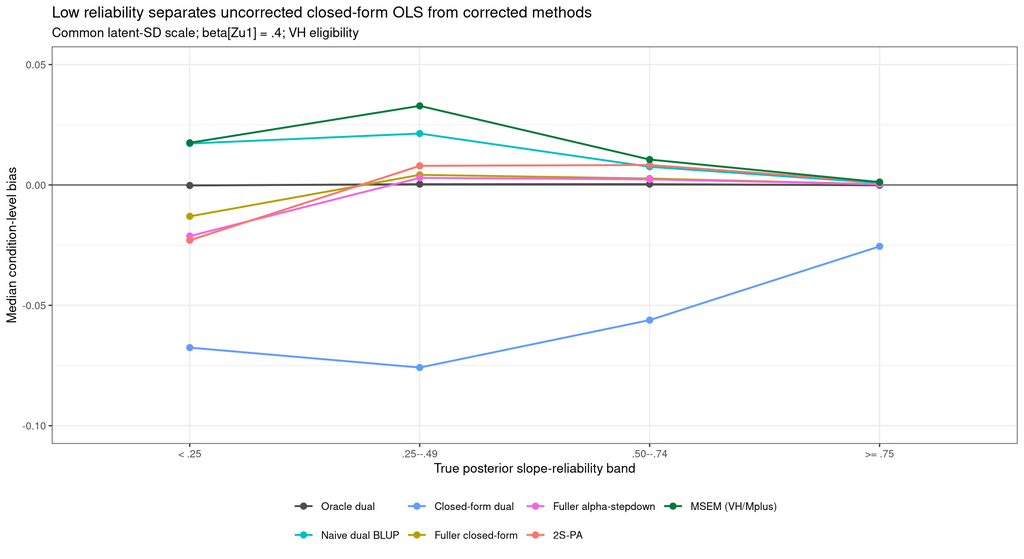

Descriptive median bias across posterior-reliability bands in the Lai DGM. Reliability is emergent here, so these are associations rather than isolated reliability effects.

This descriptive bridge resembles the broader VH pattern in one important respect: uncorrected closed-form OLS is negatively biased, particularly when reliability is low, and both Fuller corrections materially reduce that bias. It differs in another: the central naïve dual-BLUP bias in the Lai DGM is near zero or slightly positive across reliability bands, rather than showing the pronounced low-reliability negative raw bias observed in VH Study 2. Rare naïve-BLUP failures remain consequential, so medians, trimmed means, and tail counts should continue to accompany ordinary means.

### Reliability is not merely cluster size, but it is not isolated here

The diagnostic range within each homogeneous cluster size is wide enough to reject “reliability is just cluster size” as a description of the Lai DGM. ICC, the slope/intercept variance ratio, and random-effect correlation all matter. Nevertheless, Lai reliability is an emergent combination of these factors rather than a randomized design dimension. Associations in the plot above therefore cannot identify a pure reliability effect. The direct posterior-reliability calibration in the VH project remains essential and is the stronger design for testing reliability-specific hypotheses.

### Recommended next analyses

1. Run a bridge experiment that starts from the Lai DGM and introduces the VH reliability calibration one component at a time. Hold the raw/common reporting scale and eligibility rule fixed, then change the cluster-size design, reliability calibration, and outcome model sequentially. This will localize where the VH low-reliability negative bias enters.
2. Compare matched reliability bands across Lai and VH using median bias, 20%-trimmed bias, RMSE, and tail-failure counts. Do not rely on the mean alone for naïve BLUP, whose rare failures can dominate it.
3. Use the source-faithful OpenMx MSEM versus VH/Mplus MSEM contrast to check whether the $J=30$ coverage gap comes from model parameterization, standardization/SE propagation, or software. Then check 2S-PA interval construction and—if exact paper replication is needed—add 2S-PAB plus the centered and uncentered slope-only EB methods outside the VH bundle.
4. In VH reporting, keep raw/common latent-SD results primary and retain Lai’s historical method-specific scale only as a labeled diagnostic. Continue to show both eligibility rules and slope-SD ratios so scale, retention, and estimator effects cannot be conflated.

Overall, the replication increases confidence that the shared 2S-PA, VH/Mplus MSEM, and dual-BLUP machinery is recovering Lai’s point-estimate result, while the eighth OpenMx method is designed to provide a source-faithful historical control without changing the VH bundle. It does not explain away the different VH Study 2 pattern. Instead, it sharpens the next question: which aspect of VH’s direct reliability calibration or DGM turns the low-reliability dual-BLUP association negative on a common scale?

## Reproducibility notes

The report is parameterized. After generating the Figure 2 post-processing outputs, render it from the repository root with:

```bash
quarto render reports/lai_study1_vh_review.qmd \
  -P results_dir:outputs/lai_study1_vh_production_20260731
```

Optionally supply `figure_dir` when figures live elsewhere and `historical_figure_reference` for a locally saved copy of Lai’s published Figure 2. This report does not rerun any models or alter the aggregate output.